# KP_associations_EDA

Nouri L. BEN ZAKOUR

12 July 2018

```r
# Libraries
#install.packages("heatmaply")
#install.packages("tidyverse")

### Setting up environment and loading data

library(dplyr)
library(knitr)
library(vcd)
library(grid)

### Loading data

bap <- read.csv2("../data/KP_screening_data.csv", header = TRUE, sep = ",", na.strings = "", stringsAsFactors = FALSE)

### Summary
#summary(bap)
```

## Association analyses

Extended mosaic plot displays show the standardized residuals of a loglinear model of the counts from by the color and outline of the mosaic’s tiles. Standardized residuals are often referred to a standard normal distribution. Negative residuals are drawn in shaded of red and with broken outlines; positive ones are drawn in blue with solid outlines.

```r
bap$ompK36 = as.character(bap$ompK36)
bap$ompK35 = as.character(bap$ompK35)
bap$ST = as.character(bap$ST)
porines <- select(bap,Id,ST,Insertion,ompK36,ompK35,Year,Source,Source_edited,Source_summarised,Host,Country)
```

**Mosaic plot of the ompK35 presence/absence versus ST**

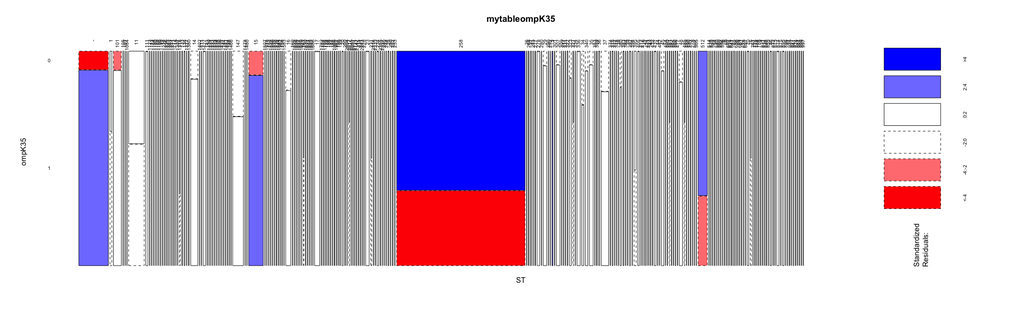

```r
porines$ST = as.character(porines$ST)

porines$Insertion <- as.factor(porines$Insertion)
levels <- levels(porines$Insertion)
levels[length(levels) + 1] <- "-"
porines$Insertion <- factor(porines$Insertion, levels = levels)
porines$Insertion[is.na(porines$Insertion)] <- "-"
porines$Insertion = as.character(porines$Insertion)

## contingency table
mytableompK35 <- xtabs(~ST+ompK35, data=porines)

## mosaic plot
mosaicplot(mytableompK35, shade = TRUE, las=2)
```

```r
# ftable creates flat contingency tables
summary(mytableompK35)
```

```
## Call: xtabs(formula = ~ST + ompK35, data = porines)
## Number of cases in table: 1557
## Number of factors: 2
## Test for independence of all factors:
##  Chisq = 603.7, df = 227, p-value = 5.748e-36
##  Chi-squared approximation may be incorrect
```

```r
## mosaic plot with expected freq
#expected35 <- mosaic(~ST+ompK35, data=porine_data, type = "expected")
#expected35
```

**Mosaic plots of the ompK36 presence/absence versus ST**

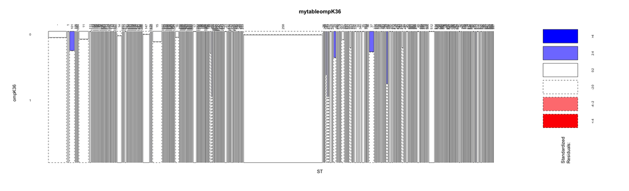

```r
mytableompK36 <- xtabs(~ST+ompK36, data=porines)  # 2-Way Frequency Table
mosaicplot(mytableompK36, shade = TRUE, las=2)
```

```r
summary(mytableompK36)  # chi-square test of indepedence
```

```
## Call: xtabs(formula = ~ST + ompK36, data = porines)
## Number of cases in table: 1557
## Number of factors: 2
## Test for independence of all factors:
##  Chisq = 207.51, df = 227, p-value = 0.8188
##  Chi-squared approximation may be incorrect
```

```r
#expected36 <- mosaic(~ST+ompK36, data=porine_data, type = "expected")
#expected36
```

**Mosaic plot of the ompK35/ompK36 presence/absence versus ST (3-way contigency table)**

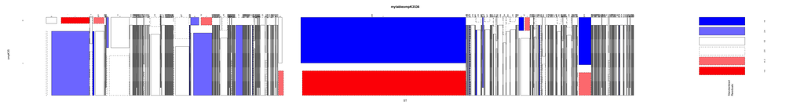

```r
# 3-way contingency table
mytableompK3536 <- xtabs(~ST+ompK35+ompK36, data=porines)
mosaicplot(mytableompK3536, shade = TRUE, las=2)
```

```r
summary(mytableompK3536)
```

```
## Call: xtabs(formula = ~ST + ompK35 + ompK36, data = porines)
## Number of cases in table: 1557
## Number of factors: 3
## Test for independence of all factors:
##  Chisq = 936.3, df = 682, p-value = 2.911e-10
##  Chi-squared approximation may be incorrect
```

**Mosaic plot of the ompK35 presence/absence and Insertion in ompK36 versus ST**

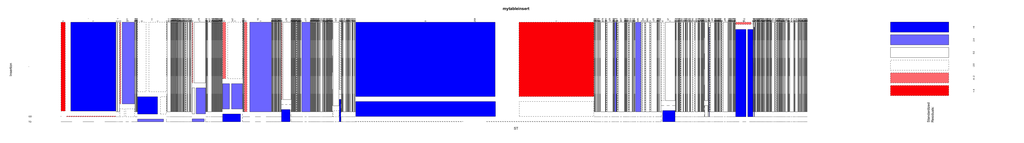

```r
mytableinsert <- xtabs(~ST+Insertion+ompK35, data=porines)  # 2-Way Frequency Table
mosaicplot(mytableinsert, shade = TRUE, las=2)
```

```r
summary(mytableinsert)  # chi-square test of independence
```

```
## Call: xtabs(formula = ~ST + Insertion + ompK35, data = porines)
## Number of cases in table: 1557
## Number of factors: 3
## Test for independence of all factors:
##  Chisq = 1654.6, df = 1137, p-value = 6.2e-22
##  Chi-squared approximation may be incorrect
```

**Mosaic plot of the Insertion + presence/absence of ompK36 versus ST and ompK35**

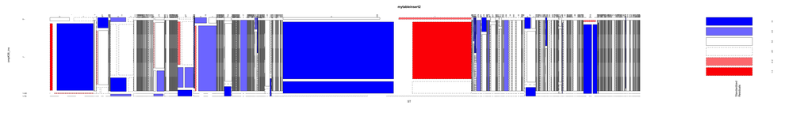

```r
# combine insertion and ompK36 presence/absence in one factor
porine_data2 <- data.frame(porines[,1:5], ompK36_ins=paste(porines[,4],porines[,3],sep="-"))
mytableinsert2 <- xtabs(~ST+ompK36_ins+ompK35, data=porine_data2)  # 2-Way Frequency Table
mosaicplot(mytableinsert2, shade = TRUE, las=2)
```

```r
summary(mytableinsert2)  # chi-square test of independence
```

```
## Call: xtabs(formula = ~ST + ompK36_ins + ompK35, data = porine_data2)
## Number of cases in table: 1557
## Number of factors: 3
## Test for independence of all factors:
##  Chisq = 1989.3, df = 1592, p-value = 3.07e-11
##  Chi-squared approximation may be incorrect
```

**Supplemental figure S8 - Mosaic plot of the Insertion + presence/absence of ompK36 versus ST and ompK35 (significant only)**

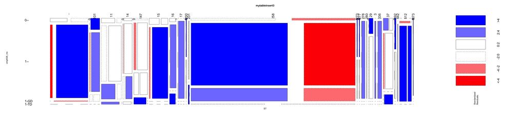

```r
# filter significantly different STs based on previous plot
significant <- c('-', '101', '11', '14', '147', '278', '280', '15', '16', '17', '120', '200', '231', '258', '127', '273', '277', '29', '278', '3', '336', '37', '392', '442', '512', '873')
porine_data2_significant <- filter(porine_data2, ST %in% significant) %>% na.omit()
mytableinsert3 <- xtabs(~ST+ompK36_ins+ompK35, data=porine_data2_significant)  # 2-Way Frequency Table

mosaicplot(mytableinsert3, shade = TRUE, las=2, cex.axis = 1.5, type="pearson")
```

```r
summary(mytableinsert3)   # chi-square test of independence
```

```
## Call: xtabs(formula = ~ST + ompK36_ins + ompK35, data = porine_data2_significant)
## Number of cases in table: 1099
## Number of factors: 3
## Test for independence of all factors:
##  Chisq = 1081.3, df = 157, p-value = 9.181e-138
##  Chi-squared approximation may be incorrect
```

**Supplemental figure S9 - Mosaic plots of ompK35 and the Insertion + presence/absence of ompK36 versus year**

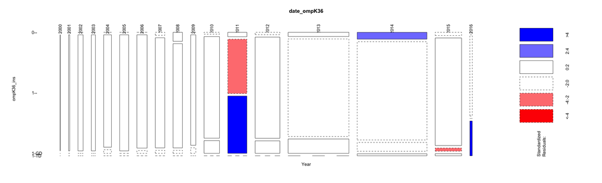

```r
porine_data_date <- select(porines,-Id)
porine_data_dateins <- data.frame(porine_data_date[,1:5], ompK36_ins=paste(porine_data_date[,3],porine_data_date[,2],sep="-"))

## OmpK36_ins by year
date_ompK36 <- xtabs(~Year+ompK36_ins, data=porine_data_dateins)
mosaicplot(date_ompK36, shade = TRUE, cex.axis = 1, las=2)
```

```r
summary(date_ompK36)
```

```
## Call: xtabs(formula = ~Year + ompK36_ins, data = porine_data_dateins)
## Number of cases in table: 1157
## Number of factors: 2
## Test for independence of all factors:
##  Chisq = 288.87, df = 48, p-value = 4.041e-36
##  Chi-squared approximation may be incorrect
```

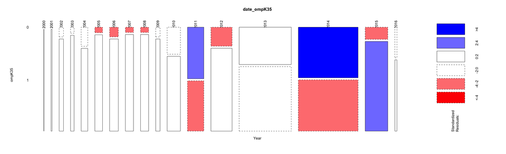

```r
## OmpK35 by year
date_ompK35 <- xtabs(~Year+ompK35, data=porine_data_dateins)
mosaicplot(date_ompK35, shade = TRUE, cex.axis = 1, las=2)
```

```r
summary(date_ompK35)
```

```
## Call: xtabs(formula = ~Year + ompK35, data = porine_data_dateins)
## Number of cases in table: 1157
## Number of factors: 2
## Test for independence of all factors:
##  Chisq = 157.25, df = 16, p-value = 2.884e-25
##  Chi-squared approximation may be incorrect
```

**Supplemental figure S10 - Mosaic plots of ompK35 and the Insertion + presence/absence of ompK36 versus country of origin**

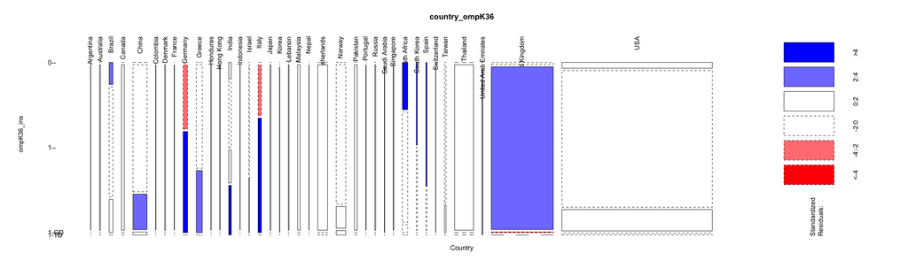

```r
porine_data_country <- select(porines,-Id)
porine_data_countryins <- data.frame(porine_data_country[,1:5], ompK36_ins=paste(porine_data_country[,3],porine_data_country[,2],sep="-"), porine_data_country[,7:10])

## OmpK36_ins by country
country_ompK36 <- xtabs(~Country+ompK36_ins, data=porine_data_countryins)
mosaicplot(country_ompK36, shade = TRUE, cex.axis = 1, las=2)
```

```r
summary(country_ompK36)
```

```
## Call: xtabs(formula = ~Country + ompK36_ins, data = porine_data_countryins)
## Number of cases in table: 1234
## Number of factors: 2
## Test for independence of all factors:
##  Chisq = 640.2, df = 108, p-value = 1.632e-76
##  Chi-squared approximation may be incorrect
```

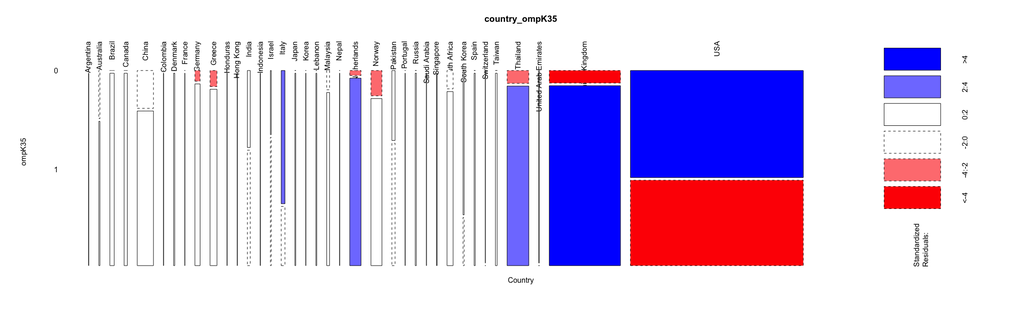

```r
## OmpK35 by country
country_ompK35 <- xtabs(~Country+ompK35, data=porine_data_countryins)
mosaicplot(country_ompK35, shade = TRUE, cex.axis = 1, las=2)
```

```r
summary(country_ompK35)
```

```
## Call: xtabs(formula = ~Country + ompK35, data = porine_data_countryins)
## Number of cases in table: 1234
## Number of factors: 2
## Test for independence of all factors:
##  Chisq = 338.1, df = 36, p-value = 8.896e-51
##  Chi-squared approximation may be incorrect
```

**Mosaic plots of ompK35 and the Insertion + presence/absence of ompK36 versus source (cleaned up)**

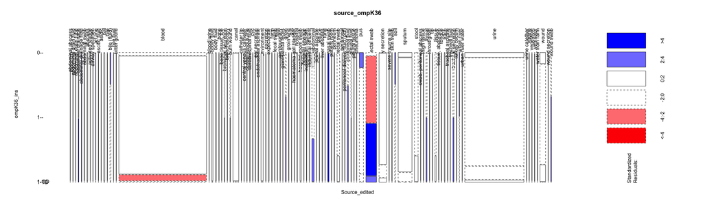

```r
porine_data_source <- select(porines,-Id)
porine_data_sourceins <- data.frame(porine_data_country[,1:5], ompK36_ins=paste(porine_data_country[,3],porine_data_country[,2],sep="-"), porine_data_country[,7:10])

## OmpK36_ins by Source
#source_ompK36 <- xtabs(~Source_summarised+ompK36_ins, data=porine_data_sourceins)
source_ompK36 <- xtabs(~Source_edited+ompK36_ins, data=porine_data_sourceins)
mosaicplot(source_ompK36, shade = TRUE, cex.axis = 1, las=2)
```

```r
summary(source_ompK36)
```

```
## Call: xtabs(formula = ~Source_edited + ompK36_ins, data = porine_data_sourceins)
## Number of cases in table: 994
## Number of factors: 2
## Test for independence of all factors:
##  Chisq = 421.2, df = 291, p-value = 8.798e-07
##  Chi-squared approximation may be incorrect
```

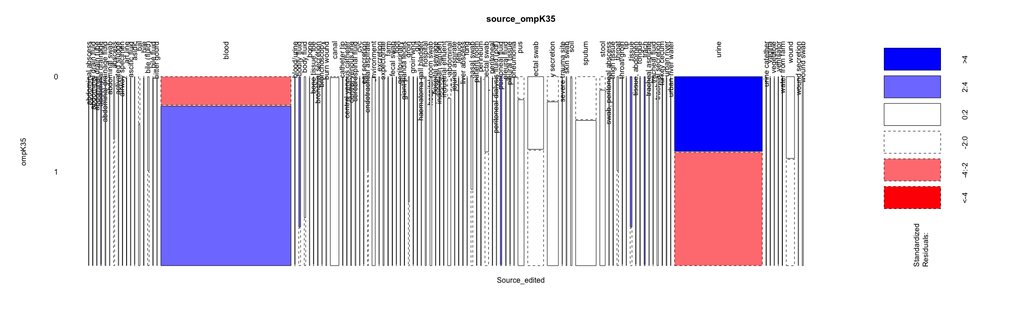

```r
## OmpK35 by Source
source_ompK35 <- xtabs(~Source_edited+ompK35, data=porine_data_sourceins)
mosaicplot(source_ompK35, shade = TRUE, cex.axis = 1, las=2)
```

```r
summary(source_ompK35)
```

```
## Call: xtabs(formula = ~Source_edited + ompK35, data = porine_data_sourceins)
## Number of cases in table: 994
## Number of factors: 2
## Test for independence of all factors:
##  Chisq = 203.54, df = 97, p-value = 1.506e-09
##  Chi-squared approximation may be incorrect
```

**Mosaic plots of ompK35 and the Insertion + presence/absence of ompK36 versus source (combined in 6 major categories)**

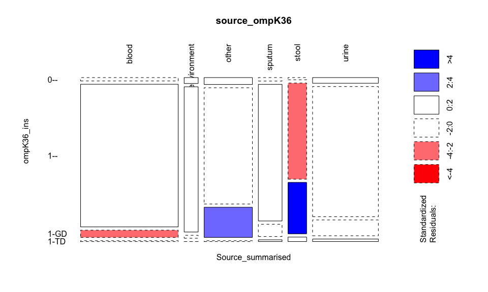

```r
porine_data_source <- select(porines,-Id)
porine_data_sourceins <- data.frame(porine_data_country[,1:5], ompK36_ins=paste(porine_data_country[,3],porine_data_country[,2],sep="-"), porine_data_country[,7:10])

## OmpK36_ins by Source
source_ompK36 <- xtabs(~Source_summarised+ompK36_ins, data=porine_data_sourceins)
mosaicplot(source_ompK36, shade = TRUE, cex.axis = 1, las=2)
```

```r
summary(source_ompK36)
```

```
## Call: xtabs(formula = ~Source_summarised + ompK36_ins, data = porine_data_sourceins)
## Number of cases in table: 994
## Number of factors: 2
## Test for independence of all factors:
##  Chisq = 79.26, df = 15, p-value = 9.535e-11
##  Chi-squared approximation may be incorrect
```

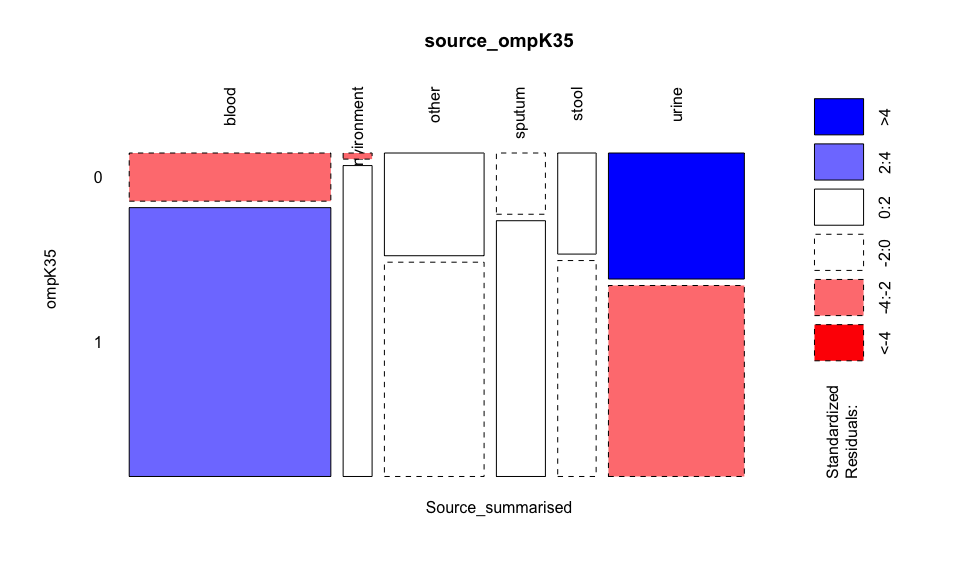

```r
## OmpK35 by Source
source_ompK35 <- xtabs(~Source_summarised+ompK35, data=porine_data_sourceins)
mosaicplot(source_ompK35, shade = TRUE, cex.axis = 1, las=2)
```

```r
summary(source_ompK35)
```

```
## Call: xtabs(formula = ~Source_summarised + ompK35, data = porine_data_sourceins)
## Number of cases in table: 994
## Number of factors: 2
## Test for independence of all factors:
##  Chisq = 69.86, df = 5, p-value = 1.095e-13
```

**Mosaic plot of ompK35, the Insertion + presence/absence of ompK36 versus source (combined in 6 major categories)**

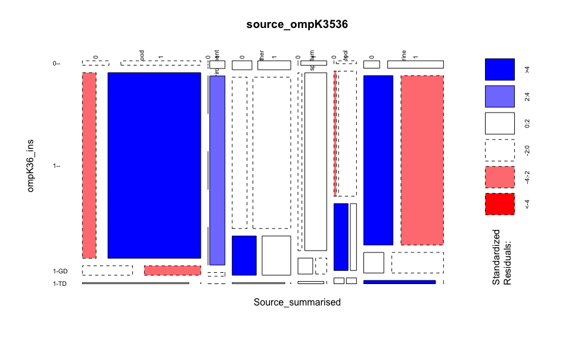

```r
source_ompK3536 <- xtabs(~Source_summarised+ompK36_ins+ompK35, data=porine_data_sourceins)
mosaicplot(source_ompK3536, shade = TRUE, las=2)
```

```r
#summary(source_ompK3536)
```